# Predicting Heart Failure through clincal data

Berkeley D. Willis

This similar in nature to a previous project where I had looked and did analysis on heart failure data. However, this time I am going to look further, and at new features to see if it is possible to accurately predict death from heart disease. To do this I will be building multiple models, and to avoid issues in the slight randomization of the splits they will be run multiple times and with the results averaged.

First I will need to get the libraries required to not only build the models but to manipulate the data.

```r
# First let's go grab the libraries that are we likely to use here and rest of the env
library(plyr)
library(dplyr)
library(reshape2)
library(caret)
library(data.table)
```

```r
library(ggplot2)
library(e1071)
library(rpart)
library(randomForest)
```

With the libraries in place, it is now time to pull the data from the filesystem, and start doing some basic operations on it.

For many of the models, for the simplicity that is, many of the numbers to boolean values. This will make it a bit easier to look at in visualization or in tabular form, and when aggregated it will seem a bit more straight forward.

Other data cleaning operations here will be things like converting to integers or treating the sex variable as a factor.

```r
hf_records_dt = fread("data/heart_failure_clinical_records_dataset.csv")

# Going to keep a semi-matrix based version of this, or at least one that is purely numbers and can be put into matrix format quickly
# for certain other tests
hf_records_raw_dt = hf_records_dt

correlation_data = round(cor(hf_records_dt), digits=2)
# Get upper triangle for viz
correlation_data[lower.tri(correlation_data)] = NA

hf_records_dt %>% head
```

```
##    age anaemia creatinine_phosphokinase diabetes ejection_fraction high_blood_pressure platelets serum_creatinine serum_sodium sex smoking time DEATH_EVENT
## 1:  75       0                      582        0                20                   1    265000              1.9          130   1       0    4           1
## 2:  55       0                     7861        0                38                   0    263358              1.1          136   1       0    6           1
## 3:  65       0                      146        0                20                   0    162000              1.3          129   1       1    7           1
## 4:  50       1                      111        0                20                   0    210000              1.9          137   1       0    7           1
## 5:  65       1                      160        1                20                   0    327000              2.7          116   0       0    8           1
## 6:  90       1                       47        0                40                   1    204000              2.1          132   1       1    8           1
```

```r
# Let's start to see some of the possible data issues such as large numbers of NA's
hf_records_dt %>% summary
```

```
##       age           anaemia       creatinine_phosphokinase    diabetes      ejection_fraction high_blood_pressure   platelets      serum_creatinine  serum_sodium        sex            smoking            time        DEATH_EVENT
##  Min.   :40.00   Min.   :0.0000   Min.   :  23.0           Min.   :0.0000   Min.   :14.00     Min.   :0.0000      Min.   : 25100   Min.   :0.500    Min.   :113.0   Min.   :0.0000   Min.   :0.0000   Min.   :  4.0   Min.   :0.0000
##  1st Qu.:51.00   1st Qu.:0.0000   1st Qu.: 116.5           1st Qu.:0.0000   1st Qu.:30.00     1st Qu.:0.0000      1st Qu.:212500   1st Qu.:0.900    1st Qu.:134.0   1st Qu.:0.0000   1st Qu.:0.0000   1st Qu.: 73.0   1st Qu.:0.0000
##  Median :60.00   Median :0.0000   Median : 250.0           Median :0.0000   Median :38.00     Median :0.0000      Median :262000   Median :1.100    Median :137.0   Median :1.0000   Median :0.0000   Median :115.0   Median :0.0000
##  Mean   :60.83   Mean   :0.4314   Mean   : 581.8           Mean   :0.4181   Mean   :38.08     Mean   :0.3512      Mean   :263358   Mean   :1.394    Mean   :136.6   Mean   :0.6488   Mean   :0.3211   Mean   :130.3   Mean   :0.3211
##  3rd Qu.:70.00   3rd Qu.:1.0000   3rd Qu.: 582.0           3rd Qu.:1.0000   3rd Qu.:45.00     3rd Qu.:1.0000      3rd Qu.:303500   3rd Qu.:1.400    3rd Qu.:140.0   3rd Qu.:1.0000   3rd Qu.:1.0000   3rd Qu.:203.0   3rd Qu.:1.0000
##  Max.   :95.00   Max.   :1.0000   Max.   :7861.0           Max.   :1.0000   Max.   :80.00     Max.   :1.0000      Max.   :850000   Max.   :9.400    Max.   :148.0   Max.   :1.0000   Max.   :1.0000   Max.   :285.0   Max.   :1.0000
```

```r
# So from what we can see there doesn't need to be any major NA issues, but there might be some better
# vector types for some of these values

# Going to convert some 0/1 values to TRUE FALSE for ease of looking and sampling inside the data
# Will look clearer in the summaries and the graphs that will be used to further explore the data

# First convert those that are best to be used as booleans
hf_records_dt$anaemia = as.logical(hf_records_dt$anaemia)
hf_records_dt$diabetes = as.logical(hf_records_dt$diabetes)
hf_records_dt$high_blood_pressure = as.logical(hf_records_dt$high_blood_pressure)
hf_records_dt$smoking = as.logical(hf_records_dt$smoking)
hf_records_dt$DEATH_EVENT = as.logical(hf_records_dt$DEATH_EVENT)

# Sex currently represented as a number, won't be consider a classification so
# we'll change it to a factor
hf_records_dt$sex = as.factor(as.character(hf_records_dt$sex))

# Finally lets change numeric to integer for age
hf_records_dt$age = as.integer(hf_records_dt$age)
```

With the data in a better place we can start to look at some various aspects of the data.

Quick easy thing to chekcout is a summary

```r
hf_records_dt %>% summary
```

```
##       age         anaemia        creatinine_phosphokinase  diabetes       ejection_fraction high_blood_pressure   platelets      serum_creatinine  serum_sodium   sex      smoking             time       DEATH_EVENT
##  Min.   :40.00   Mode :logical   Min.   :  23.0           Mode :logical   Min.   :14.00     Mode :logical       Min.   : 25100   Min.   :0.500    Min.   :113.0   0:105   Mode :logical   Min.   :  4.0   Mode :logical
##  1st Qu.:51.00   FALSE:170       1st Qu.: 116.5           FALSE:174       1st Qu.:30.00     FALSE:194           1st Qu.:212500   1st Qu.:0.900    1st Qu.:134.0   1:194   FALSE:203       1st Qu.: 73.0   FALSE:203
##  Median :60.00   TRUE :129       Median : 250.0           TRUE :125       Median :38.00     TRUE :105           Median :262000   Median :1.100    Median :137.0           TRUE :96        Median :115.0   TRUE :96
##  Mean   :60.83                   Mean   : 581.8                           Mean   :38.08                         Mean   :263358   Mean   :1.394    Mean   :136.6                           Mean   :130.3
##  3rd Qu.:70.00                   3rd Qu.: 582.0                           3rd Qu.:45.00                         3rd Qu.:303500   3rd Qu.:1.400    3rd Qu.:140.0                           3rd Qu.:203.0
##  Max.   :95.00                   Max.   :7861.0                           Max.   :80.00                         Max.   :850000   Max.   :9.400    Max.   :148.0                           Max.   :285.0
```

This gives a good idea of what is available and the general state of the data. Nothing is necessarily going to be conclusive here, but we can see certain aspects of the data. For example there is a particular gender that is more represented here, and many don’t really suffer from high blood pressure.

With that said it is better to be able to see some basic visualizations showing the correlative heat map, and some visualizations of scatter plots between a set of variables.

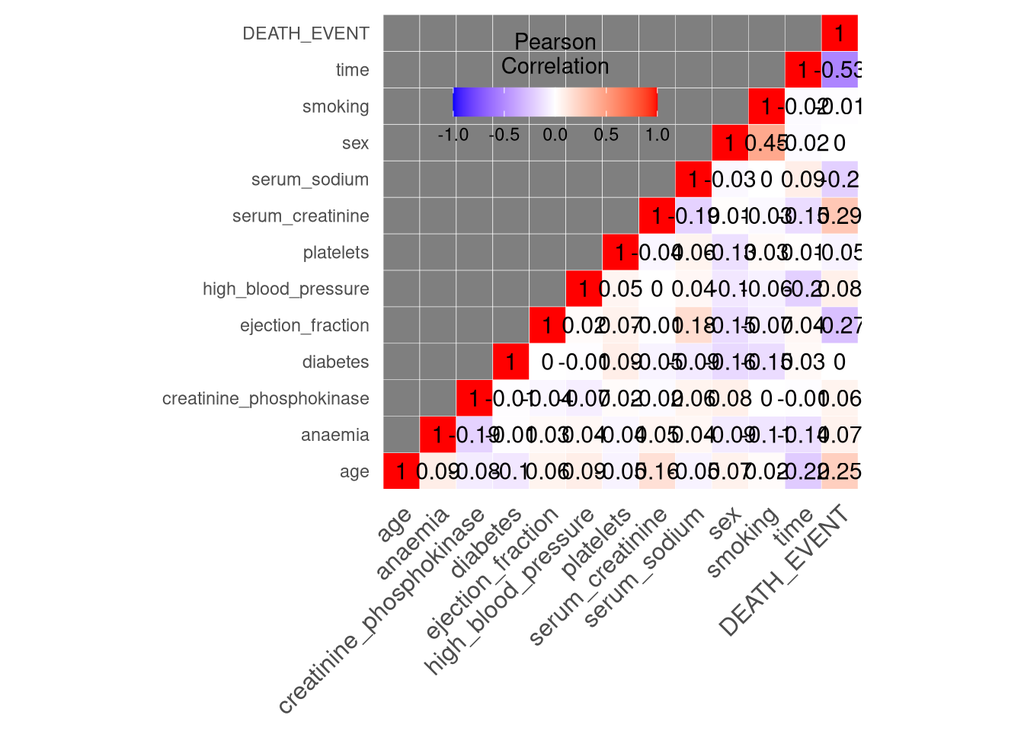

```r
# Heat map of the raw data
ggplot(data=reshape2::melt(correlation_data), aes(Var2, Var1, fill = value))+
 geom_tile(color = "white")+
 scale_fill_gradient2(low = "blue", high = "red", mid = "white",
   midpoint = 0, limit = c(-1,1), space = "Lab",
    name="Pearson\nCorrelation") +
  theme_minimal()+ # minimal theme
 theme(axis.text.x = element_text(angle = 45, vjust = 1,
    size = 12, hjust = 1))+
 coord_fixed() +
 geom_text(aes(Var2, Var1, label = value), color = "black", size = 4) +
theme(
  axis.title.x = element_blank(),
  axis.title.y = element_blank(),
  panel.grid.major = element_blank(),
  panel.border = element_blank(),
  panel.background = element_blank(),
  axis.ticks = element_blank(),
  legend.justification = c(1, 0),
  legend.position = c(0.6, 0.7),
  legend.direction = "horizontal")+
  guides(fill = guide_colorbar(barwidth = 7, barheight = 1,
                title.position = "top", title.hjust = 0.5))
```

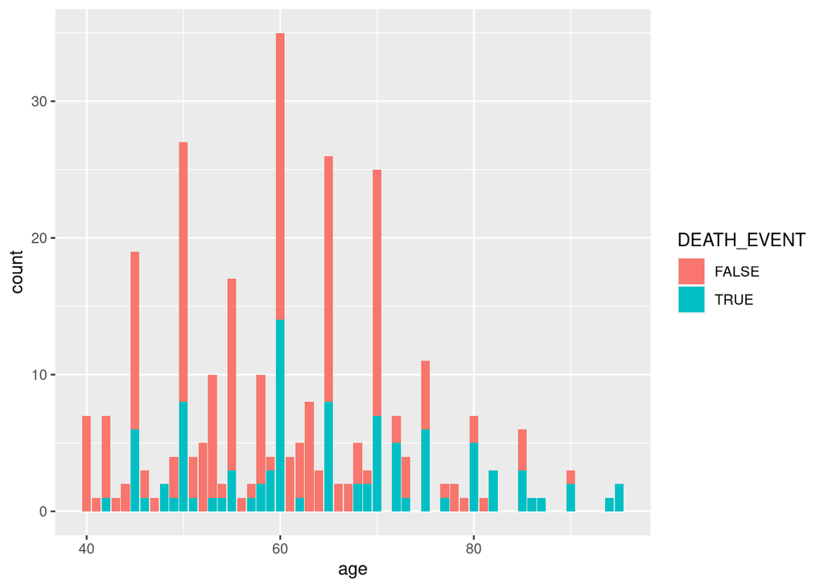

```r
hf_records_agg = setNames(
  aggregate(anaemia ~ age + DEATH_EVENT, hf_records_dt, length),
  c("age", "DEATH_EVENT", "count"))
ggplot(hf_records_agg, aes(x=age, y=count, fill=DEATH_EVENT)) +
  geom_bar(position="stack", stat="identity")
```

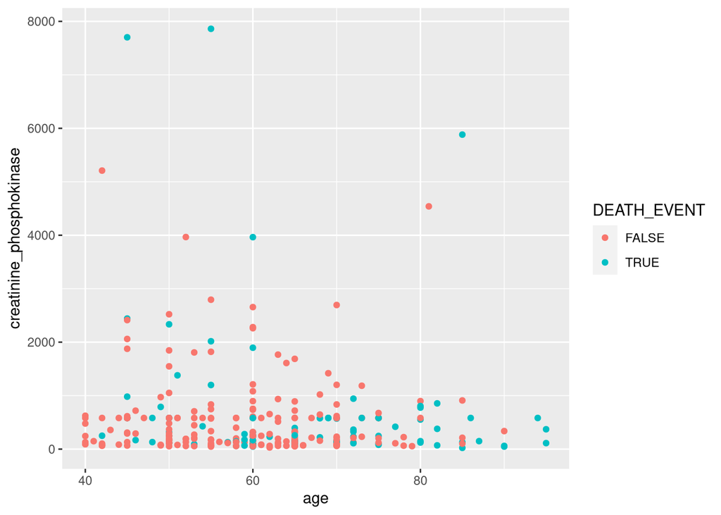

```r
ggplot(hf_records_dt, aes(x=age,y=creatinine_phosphokinase, color=DEATH_EVENT))+
    geom_point()
```

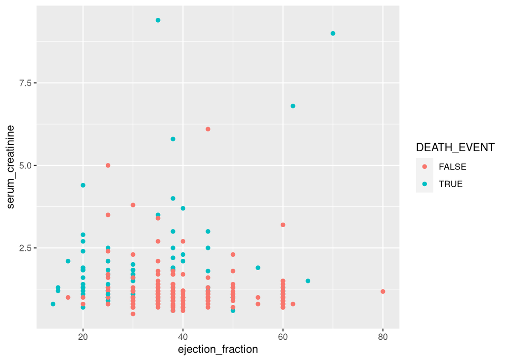

```r
ggplot(hf_records_dt, aes(x=ejection_fraction,y=serum_creatinine, color=DEATH_EVENT))+
    geom_point()
```

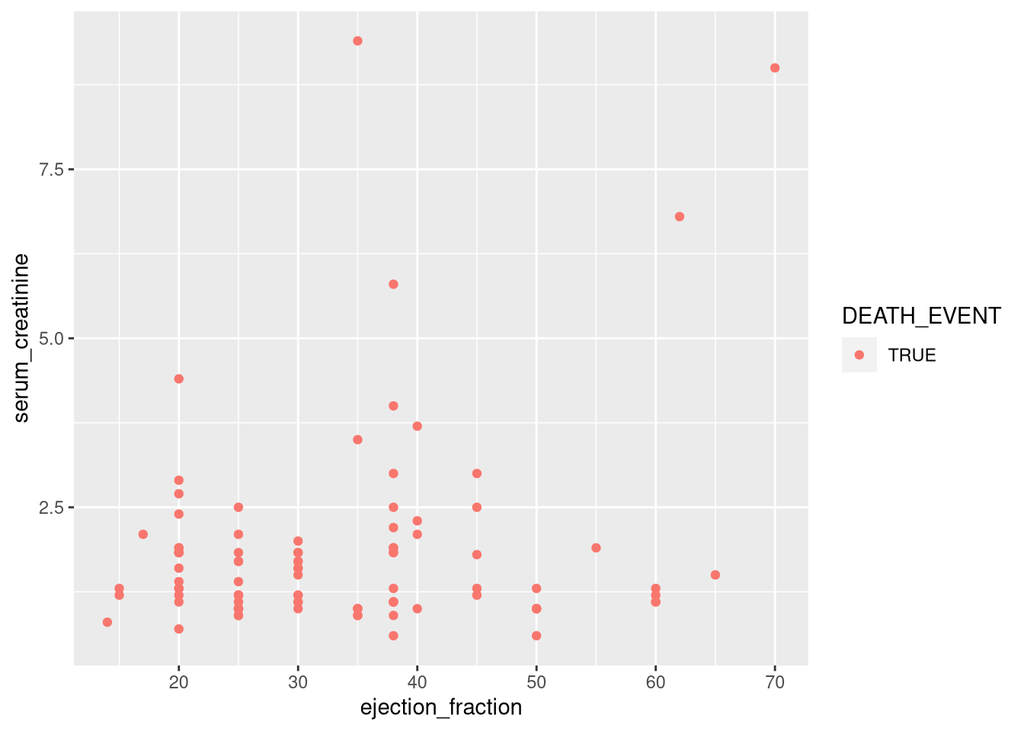

```r
ggplot(hf_records_dt[ hf_records_dt$DEATH_EVENT ], aes(x=ejection_fraction,y=serum_creatinine, color=DEATH_EVENT))+
    geom_point()
```

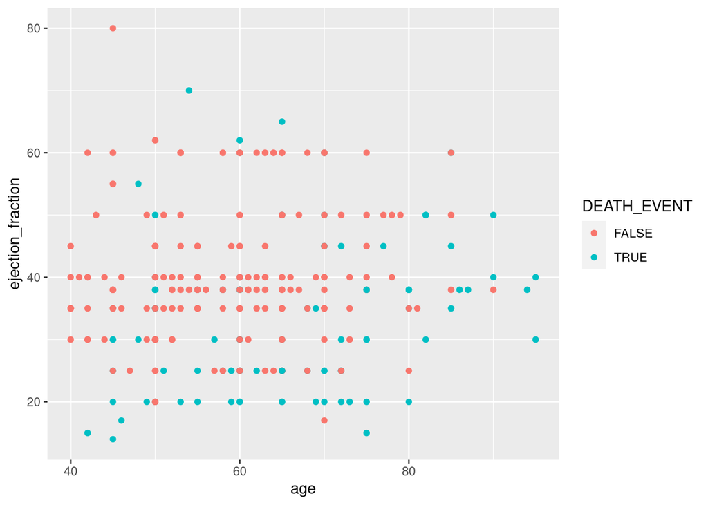

```r
ggplot(hf_records_dt, aes(x=age, y=ejection_fraction, color=DEATH_EVENT)) +
    geom_point()
```

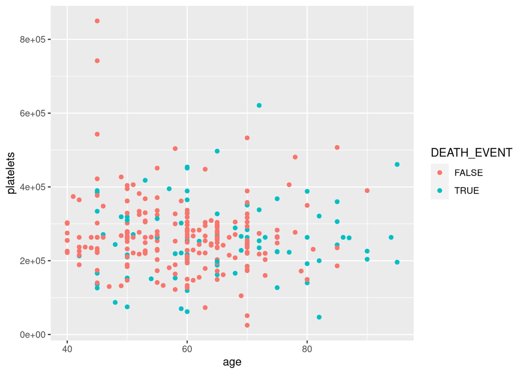

```r
ggplot(hf_records_dt, aes(x=age, y=platelets, color=DEATH_EVENT)) +
    geom_point()
```

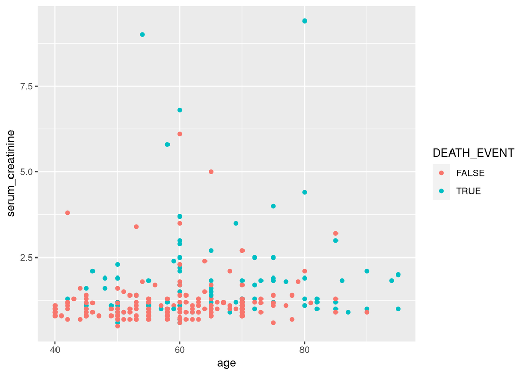

```r
ggplot(hf_records_dt, aes(x=age, y=serum_creatinine, color=DEATH_EVENT)) +
    geom_point()
```

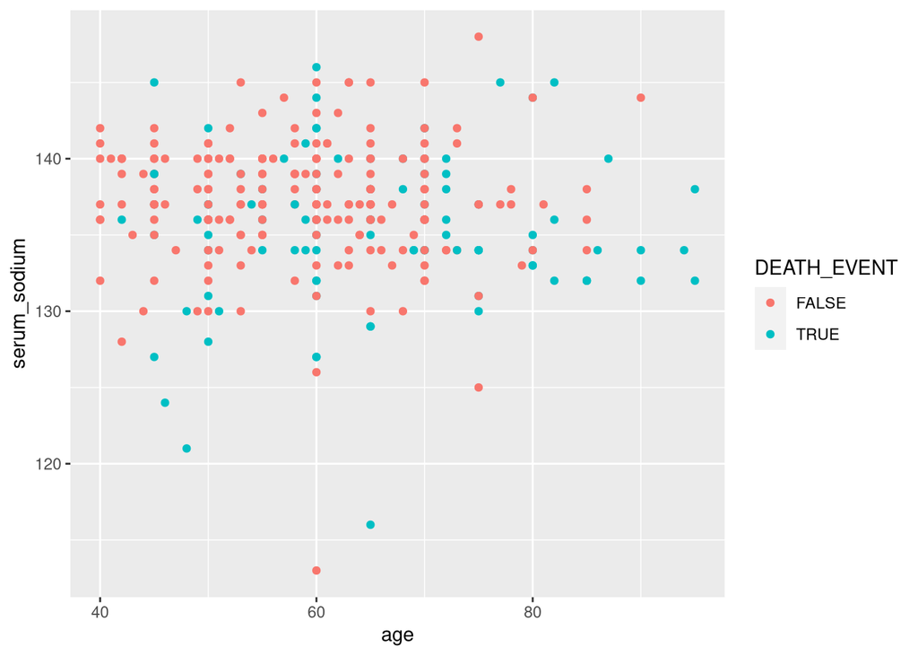

```r
ggplot(hf_records_dt, aes(x=age, y=serum_sodium, color=DEATH_EVENT)) +
    geom_point()
```

Now that there is a better understanding of the relationships, and of course some assumptions from some interpretations of what each measure represents, models can be created.

The basic idea here is going to be trying to take a bunch of the features, and slowly pruning them back and seeing what the effect is overall.

```r
# First let's identify some possible formulas here, going from complex with a bunch of stuff to simpler to prune
formula1 = DEATH_EVENT ~ age + anaemia + creatinine_phosphokinase + diabetes + ejection_fraction + high_blood_pressure + platelets + serum_creatinine + sex + serum_sodium + smoking
formula2 = DEATH_EVENT ~ age + anaemia + creatinine_phosphokinase + diabetes + ejection_fraction + high_blood_pressure + serum_creatinine + sex + serum_sodium + smoking

# Is it better to have the serum measure or just diabetes indicator?
formula3 = DEATH_EVENT ~ age + anaemia + creatinine_phosphokinase + diabetes + ejection_fraction + high_blood_pressure  + sex + serum_sodium + smoking
formula4 = DEATH_EVENT ~ age + anaemia + creatinine_phosphokinase  + ejection_fraction + high_blood_pressure + serum_creatinine + sex + serum_sodium + smoking
```

Now with the formulas we can start to build some of the functions that will help run the test many times to get an average and go ahead with the test.

```r
# Logisitic regression, multiple kinds of distributions since this isn't exactly a "normal" distrobution
runLogisticModeling = function(data, formula, split_p=0.8, ...){
  # Going to split off and create 4 indicex splits
  index1 = sample(1:nrow(data), size=round(nrow(data)*split_p))
  index2 = sample(1:nrow(data), size=round(nrow(data)*split_p))
  index3 = sample(1:nrow(data), size=round(nrow(data)*split_p))
  index4 = sample(1:nrow(data), size=round(nrow(data)*split_p))
  index5 = sample(1:nrow(data), size=round(nrow(data)*split_p))
  index6 = sample(1:nrow(data), size=round(nrow(data)*split_p))
  index7 = sample(1:nrow(data), size=round(nrow(data)*split_p))
  index8 = sample(1:nrow(data), size=round(nrow(data)*split_p))
  index9 = sample(1:nrow(data), size=round(nrow(data)*split_p))
  index10 = sample(1:nrow(data), size=round(nrow(data)*split_p))

  # For each one of these we are going to bebuilding the glm logisitic model
  model1 = glm(formula, data[index1,], family=binomial(link="logit"), ...)
  model2 = glm(formula, data[index2,], family=binomial(link="logit"), ...)
  model3 = glm(formula, data[index3,], family=binomial(link="logit"), ...)
  model4 = glm(formula, data[index4,], family=binomial(link="logit"), ...)
  model5 = glm(formula, data[index5,], family=binomial(link="logit"), ...)
  model6 = glm(formula, data[index6,], family=binomial(link="logit"), ...)
  model7 = glm(formula, data[index7,], family=binomial(link="logit"), ...)
  model8 = glm(formula, data[index8,], family=binomial(link="logit"), ...)
  model9 = glm(formula, data[index9,], family=binomial(link="logit"), ...)
  model10 = glm(formula, data[index10,], family=binomial(link="logit"), ...)

  # Now we are going to run the various predictions
  predict1 = round(predict(model1, data[!index1,], type="response"))
  predict2 = round(predict(model2, data[!index2,], type="response"))
  predict3 = round(predict(model3, data[!index3,], type="response"))
  predict4 = round(predict(model4, data[!index4,], type="response"))
  predict5 = round(predict(model5, data[!index5,], type="response"))
  predict6 = round(predict(model6, data[!index6,], type="response"))
  predict7 = round(predict(model7, data[!index7,], type="response"))
  predict8 = round(predict(model8, data[!index8,], type="response"))
  predict9 = round(predict(model9, data[!index9,], type="response"))
  predict10 = round(predict(model10, data[!index10,], type="response"))

  # Now for confusion matrices
  conf1 = confusionMatrix(table(predict1, as.integer(unlist(data[!index1, "DEATH_EVENT"]))))
  conf2 = confusionMatrix(table(predict2, as.integer(unlist(data[!index2, "DEATH_EVENT"]))))
  conf3 = confusionMatrix(table(predict3, as.integer(unlist(data[!index3, "DEATH_EVENT"]))))
  conf4 = confusionMatrix(table(predict4, as.integer(unlist(data[!index4, "DEATH_EVENT"]))))
  conf5 = confusionMatrix(table(predict5, as.integer(unlist(data[!index5, "DEATH_EVENT"]))))
  conf6 = confusionMatrix(table(predict6, as.integer(unlist(data[!index6, "DEATH_EVENT"]))))
  conf7 = confusionMatrix(table(predict7, as.integer(unlist(data[!index7, "DEATH_EVENT"]))))
  conf8 = confusionMatrix(table(predict8, as.integer(unlist(data[!index8, "DEATH_EVENT"]))))
  conf9 = confusionMatrix(table(predict9, as.integer(unlist(data[!index9, "DEATH_EVENT"]))))
  conf10 = confusionMatrix(table(predict10, as.integer(unlist(data[!index10, "DEATH_EVENT"]))))

  return(mean(conf1$overall[1],conf2$overall[1],conf3$overall[1],conf4$overall[1],conf5$overall[1],conf6$overall[1],conf7$overall[1],conf8$overall[1],conf9$overall[1],conf10$overall[1]))
}
```

```r
getAvgLogisticAccuracy = function(data, formula, p_split=0.8, iters=1000){
  accs = sapply(1:iters, function(x, p_df, p_split){
    y = x
    index = sample(1:nrow(p_df), size=round(nrow(p_df)*p_split))
    model = glm(formula, p_df[index,], family=binomial(link="logit"))
    predict = round(predict(model, p_df[!index,], type="response"))
    conf = confusionMatrix(table(predict, as.integer(unlist(p_df[!index, "DEATH_EVENT"]))))
    conf$overall[1]
  }, p_df=data, p_split=p_split)
  print(paste("Average accuracy over", iters, "iterations:",mean(accs)))
}

runLogisticModeling(hf_records_dt, formula1)
```

```
## [1] 0.7
```

```r
runLogisticModeling(hf_records_dt, formula2)
```

```
## [1] 0.65
```

```r
runLogisticModeling(hf_records_dt, formula3)
```

```
## [1] 0.7666667
```

```r
runLogisticModeling(hf_records_dt, formula4)
```

```
## [1] 0.6833333
```

Now Iwant to see what the difference would be if decisions trees were utilized.

```r
getAvgDecTreeAccuracy = function(data, formula, p_split=0.8, iters=1000){
  accs = sapply(1:iters, function(x, p_df, p_split){
    y = x
    index = sample(1:nrow(p_df), size=round(nrow(p_df)*p_split))
    model = rpart(formula, p_df[index,])
    predict = round(predict(model, p_df[!index,]))
    conf = confusionMatrix(table(predict, as.integer(unlist(p_df[!index, "DEATH_EVENT"]))))
    conf$overall[1]
  }, p_df=data, p_split=p_split)
  print(paste("Average accuracy over", iters, "iterations:",mean(accs)))
}

# Now hit is up with basic decision tree, this just can take the entire dataset
runDecisionTreeModeling = function(data, formula, split_p=0.8, ...){
  # Going to split off and create 4 indicex splits
  index1 = sample(1:nrow(data), size=round(nrow(data)*split_p))
  index2 = sample(1:nrow(data), size=round(nrow(data)*split_p))
  index3 = sample(1:nrow(data), size=round(nrow(data)*split_p))
  index4 = sample(1:nrow(data), size=round(nrow(data)*split_p))
  index5 = sample(1:nrow(data), size=round(nrow(data)*split_p))
  index6 = sample(1:nrow(data), size=round(nrow(data)*split_p))
  index7 = sample(1:nrow(data), size=round(nrow(data)*split_p))
  index8 = sample(1:nrow(data), size=round(nrow(data)*split_p))
  index9 = sample(1:nrow(data), size=round(nrow(data)*split_p))
  index10 = sample(1:nrow(data), size=round(nrow(data)*split_p))

  # For each one of these we are going to bebuilding the glm logisitic model
  model1 = rpart(formula, data[index1,], ...)
  model2 = rpart(formula, data[index2,], ...)
  model3 = rpart(formula, data[index3,], ...)
  model4 = rpart(formula, data[index4,], ...)
  model5 = rpart(formula, data[index5,], ...)
  model6 = rpart(formula, data[index6,], ...)
  model7 = rpart(formula, data[index7,], ...)
  model8 = rpart(formula, data[index8,], ...)
  model9 = rpart(formula, data[index9,], ...)
  model10 = rpart(formula, data[index10,], ...)

  # Now we are going to run the various predictions
  predict1 = round(predict(model1, data[!index1,]))
  predict2 = round(predict(model2, data[!index2,]))
  predict3 = round(predict(model3, data[!index3,]))
  predict4 = round(predict(model4, data[!index4,]))
  predict5 = round(predict(model5, data[!index5,]))
  predict6 = round(predict(model6, data[!index6,]))
  predict7 = round(predict(model7, data[!index7,]))
  predict8 = round(predict(model8, data[!index8,]))
  predict9 = round(predict(model9, data[!index9,]))
  predict10 = round(predict(model10, data[!index10,]))

  # Now for confusion matrices
  conf1 = confusionMatrix(table(predict1, as.integer(unlist(data[!index1, "DEATH_EVENT"]))))
  conf2 = confusionMatrix(table(predict2, as.integer(unlist(data[!index2, "DEATH_EVENT"]))))
  conf3 = confusionMatrix(table(predict3, as.integer(unlist(data[!index3, "DEATH_EVENT"]))))
  conf4 = confusionMatrix(table(predict4, as.integer(unlist(data[!index4, "DEATH_EVENT"]))))
  conf5 = confusionMatrix(table(predict5, as.integer(unlist(data[!index5, "DEATH_EVENT"]))))
  conf6 = confusionMatrix(table(predict6, as.integer(unlist(data[!index6, "DEATH_EVENT"]))))
  conf7 = confusionMatrix(table(predict7, as.integer(unlist(data[!index7, "DEATH_EVENT"]))))
  conf8 = confusionMatrix(table(predict8, as.integer(unlist(data[!index8, "DEATH_EVENT"]))))
  conf9 = confusionMatrix(table(predict9, as.integer(unlist(data[!index9, "DEATH_EVENT"]))))
  conf10 = confusionMatrix(table(predict10, as.integer(unlist(data[!index10, "DEATH_EVENT"]))))

  return(mean(conf1$overall[1],conf2$overall[1],conf3$overall[1],conf4$overall[1],conf5$overall[1],conf6$overall[1],conf7$overall[1],conf8$overall[1],conf9$overall[1],conf10$overall[1]))
}

runDecisionTreeModeling(hf_records_dt, formula1)
```

```
## [1] 0.7
```

```r
runDecisionTreeModeling(hf_records_dt, formula2)
```

```
## [1] 0.6166667
```

```r
runDecisionTreeModeling(hf_records_dt, formula3)
```

```
## [1] 0.7
```

```r
runDecisionTreeModeling(hf_records_dt, formula4)
```

```
## [1] 0.6833333
```

Now for measure the accuracy of SVMs

```r
getAvgSVMAccuracy = function(data, formula, p_split=0.8, iters=1000, ...){
  accs = sapply(1:iters, function(x, p_df, p_split){
    y = x
    index = sample(1:nrow(p_df), size=round(nrow(p_df)*p_split))
    model = svm(formula, data[index,], type="one-classification", ...)
    predict = predict(model, data[!index,])
    conf = confusionMatrix(table(predict, as.logical(unlist(p_df[!index, "DEATH_EVENT"]))))
    conf$overall[1]
  }, p_df=data, p_split=p_split)
  print(paste("Average accuracy over", iters, "iterations:",mean(accs)))
}

# SVM? It is possible here
runSVMModeling = function(data, formula, split_p=0.8, ...){
  # Going to split off and create 4 indicex splits
  index1 = sample(1:nrow(data), size=round(nrow(data)*split_p))
  index2 = sample(1:nrow(data), size=round(nrow(data)*split_p))
  index3 = sample(1:nrow(data), size=round(nrow(data)*split_p))
  index4 = sample(1:nrow(data), size=round(nrow(data)*split_p))
  index5 = sample(1:nrow(data), size=round(nrow(data)*split_p))
  index6 = sample(1:nrow(data), size=round(nrow(data)*split_p))
  index7 = sample(1:nrow(data), size=round(nrow(data)*split_p))
  index8 = sample(1:nrow(data), size=round(nrow(data)*split_p))
  index9 = sample(1:nrow(data), size=round(nrow(data)*split_p))
  index10 = sample(1:nrow(data), size=round(nrow(data)*split_p))

  # For each one of these we are going to bebuilding the glm logisitic model
  model1  = svm(formula, data[index1,], type="one-classification", ...)
  model2  = svm(formula, data[index2,], type="one-classification", ...)
  model3  = svm(formula, data[index3,], type="one-classification", ...)
  model4  = svm(formula, data[index4,], type="one-classification", ...)
  model5  = svm(formula, data[index5,], type="one-classification", ...)
  model6  = svm(formula, data[index6,], type="one-classification", ...)
  model7  = svm(formula, data[index7,], type="one-classification", ...)
  model8  = svm(formula, data[index8,], type="one-classification", ...)
  model9  = svm(formula, data[index9,], type="one-classification", ...)
  model10 = svm(formula, data[index10,], type="one-classification", ...)

  # Now we are going to run the various predictions
  predict1 = predict(model1, data[!index1,])
  predict2 = predict(model2, data[!index2,])
  predict3 = predict(model3, data[!index3,])
  predict4 = predict(model4, data[!index4,])
  predict5 = predict(model5, data[!index5,])
  predict6 = predict(model6, data[!index6,])
  predict7 = predict(model7, data[!index7,])
  predict8 = predict(model8, data[!index8,])
  predict9 = predict(model9, data[!index9,])
  predict10 = predict(model10, data[!index10,])

  # Now for confusion matrices
  conf1 = confusionMatrix(table(predict1, as.logical(unlist(data[!index1, "DEATH_EVENT"]))))
  conf2 = confusionMatrix(table(predict2, as.logical(unlist(data[!index2, "DEATH_EVENT"]))))
  conf3 = confusionMatrix(table(predict3, as.logical(unlist(data[!index3, "DEATH_EVENT"]))))
  conf4 = confusionMatrix(table(predict4, as.logical(unlist(data[!index4, "DEATH_EVENT"]))))
  conf5 = confusionMatrix(table(predict5, as.logical(unlist(data[!index5, "DEATH_EVENT"]))))
  conf6 = confusionMatrix(table(predict6, as.logical(unlist(data[!index6, "DEATH_EVENT"]))))
  conf7 = confusionMatrix(table(predict7, as.logical(unlist(data[!index7, "DEATH_EVENT"]))))
  conf8 = confusionMatrix(table(predict8, as.logical(unlist(data[!index8, "DEATH_EVENT"]))))
  conf9 = confusionMatrix(table(predict9, as.logical(unlist(data[!index9, "DEATH_EVENT"]))))
  conf10 = confusionMatrix(table(predict10, as.logical(unlist(data[!index10, "DEATH_EVENT"]))))

  return(mean(conf1$overall[1],conf2$overall[1],conf3$overall[1],conf4$overall[1],conf5$overall[1],conf6$overall[1],conf7$overall[1],conf8$overall[1],conf9$overall[1],conf10$overall[1]))
}

runSVMModeling(hf_records_raw_dt, formula1)
```

```
## [1] 0.4666667
```

```r
runSVMModeling(hf_records_raw_dt, formula2)
```

```
## [1] 0.4333333
```

```r
runSVMModeling(hf_records_raw_dt, formula3)
```

```
## [1] 0.5
```

```r
runSVMModeling(hf_records_raw_dt, formula4)
```

```
## [1] 0.4
```

```r
runSVMModeling(hf_records_raw_dt, formula1, kernel="linear")
```

```
## [1] 0.6333333
```

```r
runSVMModeling(hf_records_raw_dt, formula2, kernel="linear")
```

```
## [1] 0.5333333
```

```r
runSVMModeling(hf_records_raw_dt, formula3, kernel="linear")
```

```
## [1] 0.6
```

```r
runSVMModeling(hf_records_raw_dt, formula4, kernel="linear")
```

```
## [1] 0.5833333
```

```r
runSVMModeling(hf_records_raw_dt, formula1, kernel="polynomial")
```

```
## [1] 0.7
```

```r
runSVMModeling(hf_records_raw_dt, formula2, kernel="polynomial")
```

```
## [1] 0.6333333
```

```r
runSVMModeling(hf_records_raw_dt, formula3, kernel="polynomial")
```

```
## [1] 0.6166667
```

```r
runSVMModeling(hf_records_raw_dt, formula4, kernel="polynomial")
```

```
## [1] 0.6166667
```

```r
runSVMModeling(hf_records_raw_dt, formula1, kernel="sigmoid")
```

```
## [1] 0.3833333
```

```r
runSVMModeling(hf_records_raw_dt, formula2, kernel="sigmoid")
```

```
## [1] 0.5
```

```r
runSVMModeling(hf_records_raw_dt, formula3, kernel="sigmoid")
```

```
## [1] 0.2833333
```

```r
runSVMModeling(hf_records_raw_dt, formula4, kernel="sigmoid")
```

```
## [1] 0.5
```

```r
# Getting data and results for many many iterations for each model

getAvgLogisticAccuracy(hf_records_dt, formula1, iters=10000)
```

```
## [1] "Average accuracy over 10000 iterations: 0.734321666666667"
```

```r
getAvgLogisticAccuracy(hf_records_dt, formula2, iters=10000)
```

```
## [1] "Average accuracy over 10000 iterations: 0.740853333333333"
```

```r
getAvgLogisticAccuracy(hf_records_dt, formula3, iters=10000)
```

```
## [1] "Average accuracy over 10000 iterations: 0.716855"
```

```r
getAvgLogisticAccuracy(hf_records_dt, formula4, iters=10000)
```

```
## [1] "Average accuracy over 10000 iterations: 0.74271"
```

```r
getAvgDecTreeAccuracy(hf_records_dt, formula1, iters=10000)
```

```
## [1] "Average accuracy over 10000 iterations: 0.729503333333333"
```

```r
getAvgDecTreeAccuracy(hf_records_dt, formula2, iters=10000)
```

```
## [1] "Average accuracy over 10000 iterations: 0.738813333333333"
```

```r
getAvgDecTreeAccuracy(hf_records_dt, formula3, iters=10000)
```

```
## [1] "Average accuracy over 10000 iterations: 0.707071666666667"
```

```r
getAvgDecTreeAccuracy(hf_records_dt, formula4, iters=10000)
```

```
## [1] "Average accuracy over 10000 iterations: 0.73966"
```

```r
getAvgSVMAccuracy(hf_records_raw_dt, formula1, iters=10000)
```

```
## [1] "Average accuracy over 10000 iterations: 0.389563333333333"
```

```r
getAvgSVMAccuracy(hf_records_raw_dt, formula2, iters=10000)
```

```
## [1] "Average accuracy over 10000 iterations: 0.386175"
```

```r
getAvgSVMAccuracy(hf_records_raw_dt, formula3, iters=10000)
```

```
## [1] "Average accuracy over 10000 iterations: 0.405631666666667"
```

```r
getAvgSVMAccuracy(hf_records_raw_dt, formula4, iters=10000)
```

```
## [1] "Average accuracy over 10000 iterations: 0.383013333333333"
```

```r
getAvgSVMAccuracy(hf_records_raw_dt, formula1, kernel="linear", iters=10000)
```

```
## [1] "Average accuracy over 10000 iterations: 0.541125"
```

```r
getAvgSVMAccuracy(hf_records_raw_dt, formula2, kernel="linear", iters=10000)
```

```
## [1] "Average accuracy over 10000 iterations: 0.543715"
```

```r
getAvgSVMAccuracy(hf_records_raw_dt, formula3, kernel="linear", iters=10000)
```

```
## [1] "Average accuracy over 10000 iterations: 0.52378"
```

```r
getAvgSVMAccuracy(hf_records_raw_dt, formula4, kernel="linear", iters=10000)
```

```
## [1] "Average accuracy over 10000 iterations: 0.547945"
```

```r
getAvgSVMAccuracy(hf_records_raw_dt, formula1, kernel="polynomial", iters=10000)
```

```
## [1] "Average accuracy over 10000 iterations: 0.61192"
```

```r
getAvgSVMAccuracy(hf_records_raw_dt, formula2, kernel="polynomial", iters=10000)
```

```
## [1] "Average accuracy over 10000 iterations: 0.582065"
```

```r
getAvgSVMAccuracy(hf_records_raw_dt, formula3, kernel="polynomial", iters=10000)
```

```
## [1] "Average accuracy over 10000 iterations: 0.60366"
```

```r
getAvgSVMAccuracy(hf_records_raw_dt, formula4, kernel="polynomial", iters=10000)
```

```
## [1] "Average accuracy over 10000 iterations: 0.572858333333333"
```

```r
getAvgSVMAccuracy(hf_records_raw_dt, formula1, kernel="sigmoid", iters=10000)
```

```
## [1] "Average accuracy over 10000 iterations: 0.489516666666667"
```

```r
getAvgSVMAccuracy(hf_records_raw_dt, formula2, kernel="sigmoid", iters=10000)
```

```
## [1] "Average accuracy over 10000 iterations: 0.475986666666667"
```

```r
getAvgSVMAccuracy(hf_records_raw_dt, formula3, kernel="sigmoid", iters=10000)
```

```
## [1] "Average accuracy over 10000 iterations: 0.450813333333333"
```

```r
getAvgSVMAccuracy(hf_records_raw_dt, formula4, kernel="sigmoid", iters=10000)
```

```
## [1] "Average accuracy over 10000 iterations: 0.491055"
```

Finally, just a curiosity of mine. I am wondering with a combination of models, how would an ensemble being built from these models would performs. Woudl this increase their performance like just taking the average between the two raw outputs of the models, or does this lower the performance?

```r
# Testing ensemble models, but very simple ones
buildEnsemble = function(FUNCTION=mean, data_df, iters=10000, split_p=0.8, ...){
  # First going to build the logistic models based on provided formulas
  accs = sapply(1:iters, function(x, p_df, split, formulas_l){
    # First make sure param is used to avoid for loops
    y = x
    # Split the data
    index = sample(1:nrow(p_df), size=round(nrow(p_df)*split))
    # Now go through each one and build a model
    models_l = lapply(formulas_l, function(formula, model_data){
      glm(formula, model_data, family=binomial(link="logit"))
    }, model_data=p_df[index,])
    # For each model, predict them
    predictions_l = lapply(models_l, function(model, predict_data){
      predict(model, predict_data, type="response")
    }, predict_data=p_df[!index,])
    # Now attempting to aggregate for each entry, kinda messy way of doing it, but fairly simple when broken down
    # Going through each list, getting the transformation of each prediction vector, and treating is a dataframe, then
    # combined into a dataframe via a plyr rbind.fill function
    predictions_df = rbind.fill(
      lapply( predictions_l,function(prediction_c){
        as.data.frame(t(prediction_c))
      })
    )
    # Then you can just take each column and run the FUNCTION, likely the mean function
    ensembled_preds = apply(predictions_df, 2, FUNCTION)
    # After that, now we can normalize/round the prediction values
    final_preds = round(ensembled_preds)
    tmp_table = table(final_preds, as.integer(unlist(p_df[!index, "DEATH_EVENT"])))
    # Missing rows?
    fill_row = setdiff(colnames(tmp_table), rownames(tmp_table))
    if(length(fill_row)!=0){
      tmp_table = rbind(tmp_table, tmp_row=c(0,0))
      rownames(tmp_table)[ rownames(tmp_table)=="tmp_row" ] = fill_row
      tmp_table = as.table(tmp_table)
    }
    # Then create confusion matrices
    conf_mat = confusionMatrix(tmp_table)
    conf_mat$overall[1]
  }, p_df=data_df, split=split_p, formulas_l=list(...))
  print(paste("Average accuracy over", iters, "iterations:",mean(accs)))
}

buildEnsemble(mean, hf_records_dt, 10000, 0.8, formula1)
```

```
## [1] "Average accuracy over 10000 iterations: 0.735788333333333"
```

```r
buildEnsemble(mean, hf_records_dt, 10000, 0.8, DEATH_EVENT ~ age, DEATH_EVENT ~ creatinine_phosphokinase + serum_creatinine, DEATH_EVENT ~ ejection_fraction, DEATH_EVENT ~ serum_sodium)
```

```
## [1] "Average accuracy over 10000 iterations: 0.687035"
```

```r
buildEnsemble(mean, hf_records_dt, 10000, 0.8, DEATH_EVENT ~ age + high_blood_pressure + sex + smoking, DEATH_EVENT ~ anaemia + creatinine_phosphokinase + ejection_fraction + serum_creatinine  + serum_sodium)
```

```
## [1] "Average accuracy over 10000 iterations: 0.716863333333333"
```

```r
buildEnsemble(mean, hf_records_dt, 10000, 0.8, DEATH_EVENT ~ age + high_blood_pressure + sex + smoking + anaemia, DEATH_EVENT ~ creatinine_phosphokinase + ejection_fraction + serum_creatinine  + serum_sodium)
```

```
## [1] "Average accuracy over 10000 iterations: 0.71642"
```

```r
# Ok, some type of fluke? It performed very well
buildEnsemble(mean, hf_records_dt, 10000, 0.8, DEATH_EVENT ~ age + high_blood_pressure + sex + smoking + anaemia, DEATH_EVENT ~ time + ejection_fraction + serum_creatinine  + serum_sodium)
```

```
## [1] "Average accuracy over 10000 iterations: 0.806805"
```

```r
buildEnsemble(mean, hf_records_dt, 10000, 0.8, DEATH_EVENT ~ age + high_blood_pressure + sex + smoking + anaemia + time, DEATH_EVENT ~  ejection_fraction + serum_creatinine  + serum_sodium)
```

```
## [1] "Average accuracy over 10000 iterations: 0.788786666666667"
```

```r
# Let's try one more
getAvgLogisticAccuracy(hf_records_dt,  DEATH_EVENT ~ time + age + creatinine_phosphokinase  + ejection_fraction + high_blood_pressure + serum_creatinine + serum_sodium + smoking, iters=10000)
```

```
## [1] "Average accuracy over 10000 iterations: 0.823535"
```

```r
getAvgDecTreeAccuracy(hf_records_dt,  DEATH_EVENT ~ time + age + creatinine_phosphokinase  + ejection_fraction + high_blood_pressure + serum_creatinine + serum_sodium + smoking, iters=10000)
```

```
## [1] "Average accuracy over 10000 iterations: 0.810716666666667"
```

```r
getAvgLogisticAccuracy(hf_records_dt,  DEATH_EVENT ~ time + age + creatinine_phosphokinase  + ejection_fraction + high_blood_pressure + serum_creatinine + serum_sodium, iters=10000)
```

```
## [1] "Average accuracy over 10000 iterations: 0.824121666666667"
```

```r
getAvgDecTreeAccuracy(hf_records_dt,  DEATH_EVENT ~ time + age + creatinine_phosphokinase  + ejection_fraction + high_blood_pressure + serum_creatinine + serum_sodium, iters=10000)
```

```
## [1] "Average accuracy over 10000 iterations: 0.810846666666667"
```

```r
getAvgLogisticAccuracy(hf_records_dt,  DEATH_EVENT ~ time + age + creatinine_phosphokinase  + ejection_fraction + serum_creatinine + serum_sodium, iters=10000)
```

```
## [1] "Average accuracy over 10000 iterations: 0.82626"
```

```r
getAvgDecTreeAccuracy(hf_records_dt,  DEATH_EVENT ~ time + age + creatinine_phosphokinase  + ejection_fraction + serum_creatinine + serum_sodium, iters=10000)
```

```
## [1] "Average accuracy over 10000 iterations: 0.811326666666667"
```

```r
getAvgLogisticAccuracy(hf_records_dt,  DEATH_EVENT ~ time + age + ejection_fraction + serum_creatinine + serum_sodium, iters=10000)
```

```
## [1] "Average accuracy over 10000 iterations: 0.82571"
```

```r
getAvgDecTreeAccuracy(hf_records_dt,  DEATH_EVENT ~ time + age + ejection_fraction + serum_creatinine + serum_sodium, iters=10000)
```

```
## [1] "Average accuracy over 10000 iterations: 0.813896666666667"
```

```r
getAvgLogisticAccuracy(hf_records_dt,  DEATH_EVENT ~ time + creatinine_phosphokinase  + ejection_fraction + serum_creatinine + serum_sodium, iters=10000)
```

```
## [1] "Average accuracy over 10000 iterations: 0.828841666666667"
```

```r
getAvgDecTreeAccuracy(hf_records_dt,  DEATH_EVENT ~ time + creatinine_phosphokinase  + ejection_fraction + serum_creatinine + serum_sodium, iters=10000)
```

```
## [1] "Average accuracy over 10000 iterations: 0.815823333333333"
```

```r
# Best performing formula for the given data
getAvgLogisticAccuracy(hf_records_dt,  DEATH_EVENT ~ time + ejection_fraction + serum_creatinine + serum_sodium, iters=10000)
```

```
## [1] "Average accuracy over 10000 iterations: 0.831761666666667"
```

```r
getAvgDecTreeAccuracy(hf_records_dt,  DEATH_EVENT ~ time + ejection_fraction + serum_creatinine + serum_sodium, iters=10000)
```

```
## [1] "Average accuracy over 10000 iterations: 0.817465"
```

```r
getAvgLogisticAccuracy(hf_records_dt,  DEATH_EVENT ~ time + ejection_fraction + serum_sodium, iters=10000)
```

```
## [1] "Average accuracy over 10000 iterations: 0.816975"
```

```r
getAvgDecTreeAccuracy(hf_records_dt,  DEATH_EVENT ~ time + ejection_fraction + serum_sodium, iters=10000)
```

```
## [1] "Average accuracy over 10000 iterations: 0.807486666666667"
```

```r
getAvgLogisticAccuracy(hf_records_dt,  DEATH_EVENT ~ time + ejection_fraction + serum_creatinine, iters=10000)
```

```
## [1] "Average accuracy over 10000 iterations: 0.829175"
```

```r
getAvgDecTreeAccuracy(hf_records_dt,  DEATH_EVENT ~ time + ejection_fraction + serum_creatinine, iters=10000)
```

```
## [1] "Average accuracy over 10000 iterations: 0.830891666666667"
```

```r
# Gotta get SVM results now
getAvgSVMAccuracy(hf_records_raw_dt, DEATH_EVENT ~ time + ejection_fraction + serum_creatinine + serum_sodium, kernel="polynomial", iters=10000)
```

```
## [1] "Average accuracy over 10000 iterations: 0.554081666666667"
```

With all of the information that we have gathered, it seems that simplicity is of course best. With this Ihave removed all but the features that seem to perform the best.

```r
# For best models, craete one last test where we split and get the precision and recall measurements
final_index = sample(1:nrow(hf_records_dt), size=round(nrow(hf_records_dt)*0.80))
final_model = glm(DEATH_EVENT ~ time + ejection_fraction + serum_creatinine + serum_sodium, hf_records_dt[final_index,], family=binomial(link="logit"))
learning_table = confusionMatrix(table(round(final_model$fitted.values), final_model$y))

# Do performance measures on the
validation_preds = round(predict(final_model, hf_records_dt[!final_index,], type="response"))
validation_table = confusionMatrix(table(validation_preds, as.integer(unlist(hf_records_dt[ ! final_index, "DEATH_EVENT" ]))))
tmp_table = validation_table$table

validation_table
```

```
## Confusion Matrix and Statistics
##
##
## validation_preds  0  1
##                0 44  2
##                1  1 13
##
##                Accuracy : 0.95
##                  95% CI : (0.8608, 0.9896)
##     No Information Rate : 0.75
##     P-Value [Acc > NIR] : 4.736e-05
##
##                   Kappa : 0.8636
##
##  Mcnemar's Test P-Value : 1
##
##             Sensitivity : 0.9778
##             Specificity : 0.8667
##          Pos Pred Value : 0.9565
##          Neg Pred Value : 0.9286
##              Prevalence : 0.7500
##          Detection Rate : 0.7333
##    Detection Prevalence : 0.7667
##       Balanced Accuracy : 0.9222
##
##        'Positive' Class : 0
##
```

It is interesting how much change time injects here, I am curious how this feature is decided. Is there something a doctor is looking at that we don’t have access to at the moment in order to know that they should see this patient more often/sooner? Is what the doctor looking at available in raw data form, and then I would love to test the models using that data. The models built here are not really performing to the best possible, but they are hopefully something that could give an idea of those that would need to be monitored closer.